# team

Question 3:

```r
cor(choco$Cocoa_Percent, choco$Rating)
```

```
## [1] -0.1510178
```

```r
summary(choco[c("Cocoa_Percent", "Rating")])
```

```
##  Cocoa_Percent        Rating
##  Min.   : 42.00   Min.   :1.000
##  1st Qu.: 70.00   1st Qu.:3.000
##  Median : 70.00   Median :3.250
##  Mean   : 71.65   Mean   :3.184
##  3rd Qu.: 75.00   3rd Qu.:3.500
##  Max.   :100.00   Max.   :4.000
```

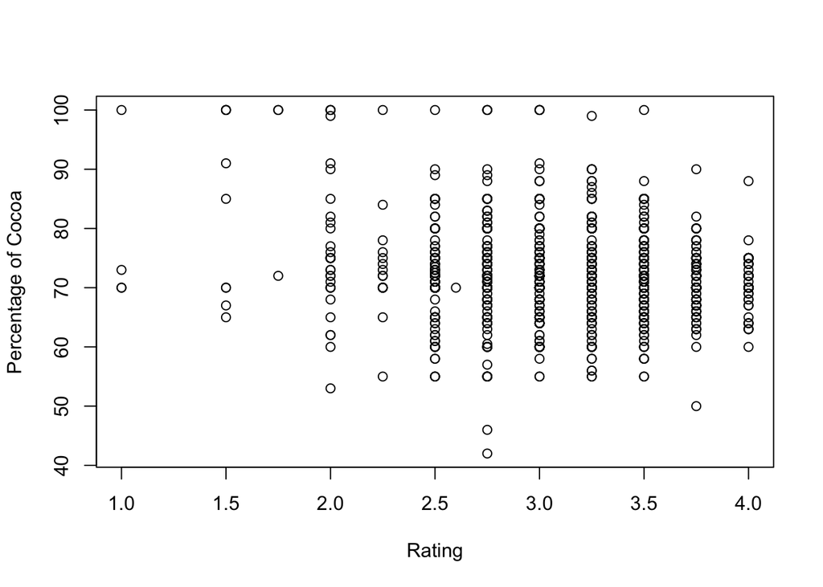

```r
plot(choco$Rating, choco$Cocoa_Percent, xlab = "Rating", ylab = "Percentage of Cocoa")
```

From this, we conclude that there isn’t a correlating between the percentage of cocoa and the rating. Notably, there is only one chocolate that has a percentage of cocoa above 80% that received a 4.0 score.

Question 4: ### Looking for which Bean_origin has a significant enough amount of counts to be useful in analysis. I am going to use the top 5, Dominican Republic, Venezuela, Ecuador, Madagascar, and Peru

```r
table(choco$Bean_Origin)
```

```
##
##             Australia                Belize                 blend
##                     3                    67                     1
##                 Blend               Bolivia                Bolvia
##                   151                    72                     1
##                Brazil                 Burma              Cameroon
##                    75                     1                     3
##              Colombia                 Congo            Costa Rica
##                    66                    11                    43
##                  Cuba    Dominican Republic              DR Congo
##                    12                   206                     1
##               Ecuador           El Salvador                  Fiji
##                   212                     6                    15
##                 Gabon                 Ghana               Grenada
##                     1                    37                    19
##             Guatemala                 Haiti              Honduras
##                    53                    24                    23
##                 India             Indonesia           Ivory Coast
##                    21                    18                     5
##               Jamaica               Liberia            Madagascar
##                    23                     3                   163
##              Malaysia            Martinique                Mexico
##                     7                     1                    46
##             Nicaragua               Nigeria                Panama
##                    92                     3                     8
##      Papua New Guinea                  Peru           Philippines
##                    49                   220                    19
##              Principe           Puerto Rico                 Samoa
##                     1                     6                     3
##              Sao Tome   Sao Tome & Principe          Sierra Leone
##                    14                     1                     3
##       Solomon Islands             Sri Lanka             St. Lucia
##                    10                     2                    10
## St.Vincent-Grenadines              Sulawesi               Sumatra
##                     1                     1                     1
##              Suriname                Taiwan              Tanzania
##                     1                     2                    64
##              Thailand                Tobago                  Togo
##                     5                     2                     3
##              Trinidad                U.S.A.                Uganda
##                    38                    30                    11
##               Vanuatu             Venezuela               Vietnam
##                    13                   245                    64
```

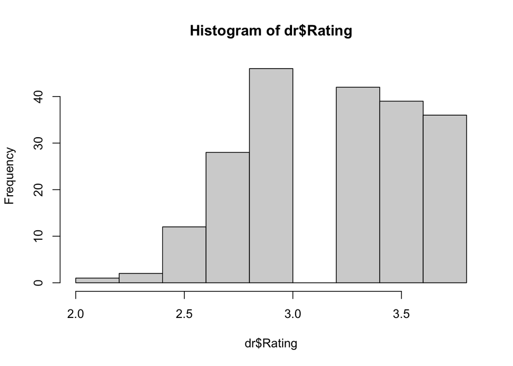

```r
dr <- choco[choco$Bean_Origin == 'Dominican Republic',]
hist(dr$Rating)
```

```r
summary(dr$Rating)
```

```
##    Min. 1st Qu.  Median    Mean 3rd Qu.    Max.
##   2.000   3.000   3.250   3.202   3.500   3.750
```

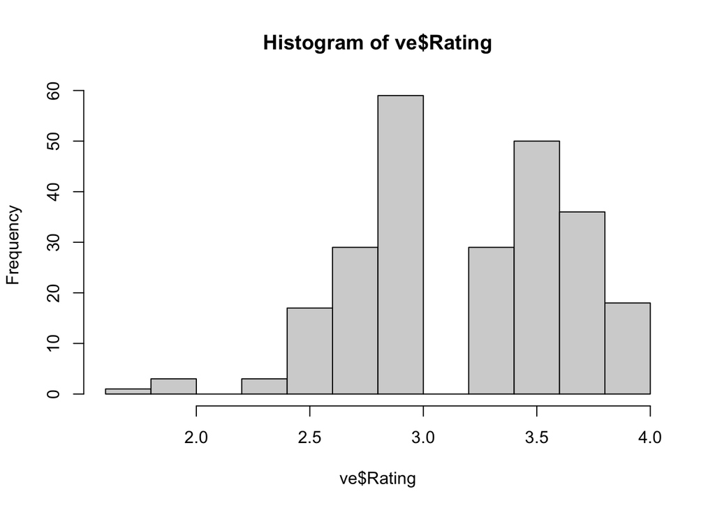

```r
ve <- choco[choco$Bean_Origin == 'Venezuela',]
hist(ve$Rating)
```

```r
summary(ve$Rating)
```

```
##    Min. 1st Qu.  Median    Mean 3rd Qu.    Max.
##   1.750   3.000   3.250   3.224   3.500   4.000
```

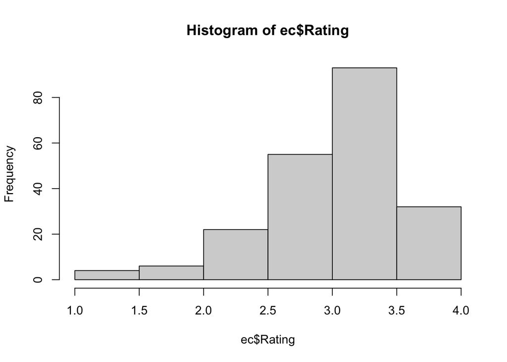

```r
ec <- choco[choco$Bean_Origin == 'Ecuador',]
hist(ec$Rating)
```

```r
summary(ec$Rating)
```

```
##    Min. 1st Qu.  Median    Mean 3rd Qu.    Max.
##   1.000   2.750   3.250   3.159   3.500   4.000
```

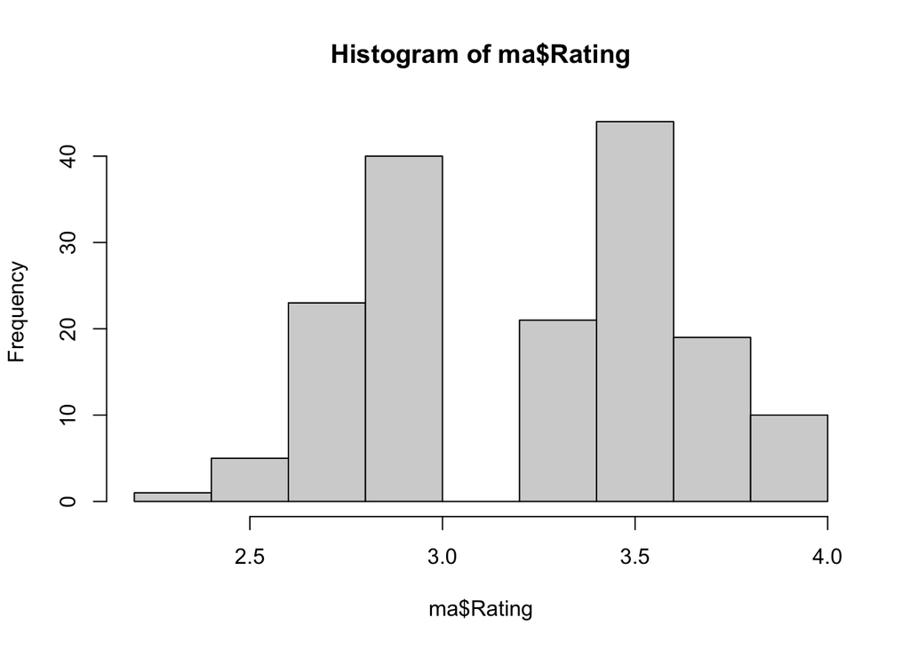

```r
ma <- choco[choco$Bean_Origin == 'Madagascar',]
hist(ma$Rating)
```

```r
summary(ma$Rating)
```

```
##    Min. 1st Qu.  Median    Mean 3rd Qu.    Max.
##   2.250   3.000   3.250   3.261   3.500   4.000
```

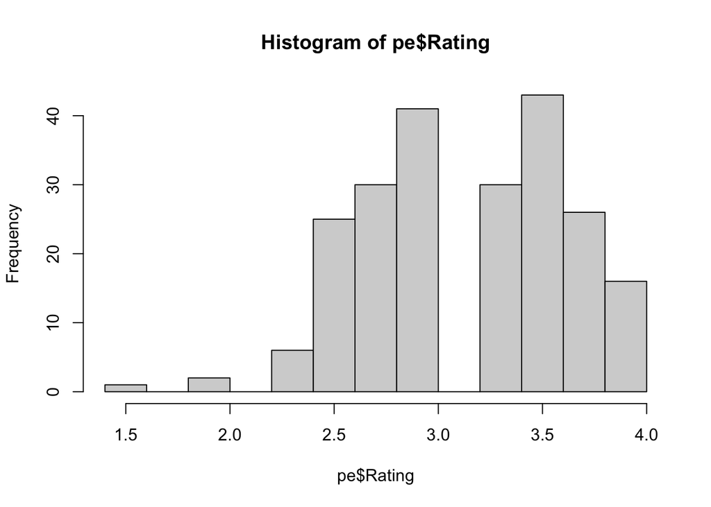

```r
pe <- choco[choco$Bean_Origin == 'Peru',]
hist(pe$Rating)
```

```r
summary(pe$Rating)
```

```
##    Min. 1st Qu.  Median    Mean 3rd Qu.    Max.
##   1.500   2.750   3.250   3.166   3.500   4.000
```